# Identifying Patients in the Hospital with Mental Health Conditions

```r
t.test(outcome_eval$AGE~outcome_eval$Received_Intervention_YN)
```

```
##
##  Welch Two Sample t-test
##
## data:  outcome_eval$AGE by outcome_eval$Received_Intervention_YN
## t = -2.4931, df = 976.51, p-value = 0.01283
## alternative hypothesis: true difference in means is not equal to 0
## 95 percent confidence interval:
##  -4.5884214 -0.5465303
## sample estimates:
## mean in group Yes  mean in group No
##          53.00413          55.57161
```

> This section evaluates whether there were changes in inpatient length of stay (LOS) after the program was initiated. An interrupted time series analysis was performed to compare level and trend changes in LOS for floors Founders 12 and 14, relative to inpatients on other floors at the Hospital of the University of Pennsylvania. Although the time series plot suggested there was a drop in average length of stay after the intervention, the results were not significant.

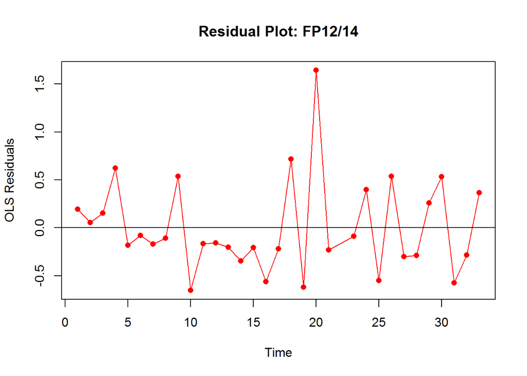

```
## integer(0)
```

```r
# Time series data
mend <- read.csv('U:/MEND/MEND_ITS_Data_Mar2017_05Dec2019.csv',header=TRUE,stringsAsFactors=FALSE)

mend_eval <- mend %>% mutate(Level = if_else(Time>=22,1,0), Trend = if_else(Time>=22,Time-21,0)) %>%
  mutate(Int_Time = if_else(Site=='FP12-14',Time,as.integer(0)),
         Int_Level = if_else(Site=='FP12-14',Level,0),
         Int_Trend = if_else(Site=='FP12-14',Trend,0)) %>%
  filter(Site %in% c("FP12-14","HUP")) %>%
  filter(Time!=34) %>%
  mutate(Site = factor(Site,levels=c("HUP","FP12-14")))

# Excl December 2018 from the model because the MEND team started piloting
mend_excl <- mend_eval %>% filter(Time!=22)

#its_model <- lm(Avg_Winsorized_Floor_Disch_Time~Site+Time+Level+Trend+Int_Time+Int_Level+Int_Trend,data=mend_excl)
its_model <- lm(Avg_Floor_Disch_Time~Site+Time+Level+Trend+Int_Time+Int_Level+Int_Trend,data=mend_excl)

coef <- data.frame(coefficients(summary(its_model)))
conf_int <- data.frame(confint(its_model))

month_labels <- unique(paste(mend_eval$Year,'-',substr(mend_eval$Month_Name,1,3),sep=''))

# Model tests
dwt_res <- dwt(its_model,max.lag=12,alternative="two.sided")
dwt <- round(data.frame(dwt_res[1]),4)

# Residual plot
par(mfrow=c(1,1))
plot(mend_excl$Time[1:32], residuals(its_model)[1:32],type='o',pch=16, col='red',
     main='Residual Plot: FP12/14', xlab='Time',ylab='OLS Residuals') +
  abline(h=0)
```

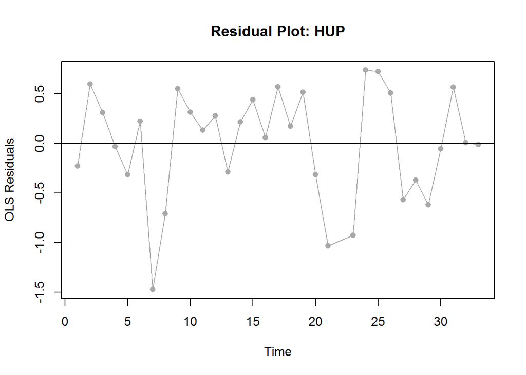

```
## integer(0)
```

```r
plot(mend_excl$Time[33:64], residuals(its_model)[33:64],type='o',pch=16, col='darkgrey',
     main='Residual Plot: HUP', xlab='Time',ylab='OLS Residuals') +
  abline(h=0)
```

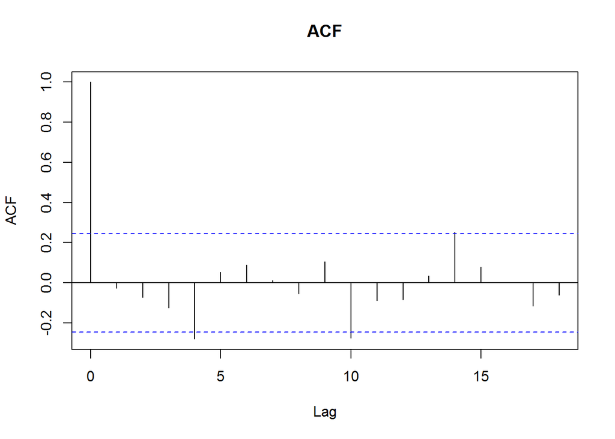

```r
par(mfrow=c(1,1))
acf(residuals(its_model),main='ACF')
```

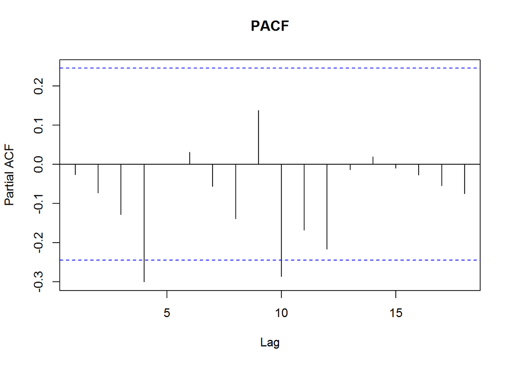

```r
acf(residuals(its_model),type='partial',main='PACF')
```

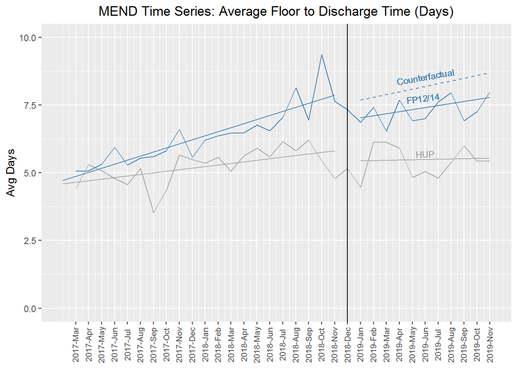

```r
# Plot
mend_eval %>% ggplot(aes(Time,Avg_Floor_Disch_Time,col=Site)) +
  geom_line() +
  scale_x_continuous(breaks=seq(1:33),labels=month_labels) +
  ggtitle("MEND Time Series: Average Floor to Discharge Time (Days)") +
  ylab("Avg Days") +
  theme(plot.title = element_text(hjust = 0.5), axis.text.x = element_text(angle = 90,size=8,vjust=0.4),
        axis.title.x=element_blank(),legend.position="none") +
  guides(colour = guide_legend(reverse=TRUE)) +
  ylim(c(0,10)) +
  #scale_y_continuous(breaks=seq(0:10), labels=c(0:10)) +
  scale_colour_manual(values=c("darkgrey","steelblue","darkgrey","steelblue")) +
  geom_vline(xintercept = 22) +
  geom_segment(aes(0,coef['(Intercept)','Estimate'],
                   xend=21,yend=coef['(Intercept)','Estimate']+21*coef['Time','Estimate']),col="darkgrey")+
  geom_segment(aes(23,coef['(Intercept)','Estimate']+23*coef['Time','Estimate']+
                     coef['Level','Estimate']+coef['Trend','Estimate'],
               xend=33,yend=coef['(Intercept)','Estimate']+33*coef['Time','Estimate']
               +coef['Level','Estimate']+10*coef['Trend','Estimate']),col="darkgrey") +
  geom_segment(aes(0,coef['(Intercept)','Estimate']+coef['SiteFP12-14','Estimate'],
               xend=21,yend=coef['(Intercept','Estimate']+coef['SiteFP12-14','Estimate']+
                 21*coef['Time','Estimate']+21*coef['Int_Time','Estimate']),col="steelblue") +
  geom_segment(aes(23,coef['(Intercept)','Estimate']+
                     coef['SiteFP12-14','Estimate']+
                     23*coef['Time','Estimate']+
                     23*coef['Int_Time','Estimate']+
                     coef['Level','Estimate']+
                     coef['Trend','Estimate']+
                     coef['Int_Level','Estimate']+
                     coef['Int_Trend','Estimate'],
               xend=33,yend=coef['(Intercept','Estimate']+coef['SiteFP12-14','Estimate']+
                 33*coef['Time','Estimate']+
                 coef['Level','Estimate']+
                 10*coef['Trend','Estimate']+
                 33*coef['Int_Time','Estimate']+
                 +coef['Int_Level','Estimate']+
                 10*coef['Int_Trend','Estimate']),col="steelblue") +
  geom_segment(aes(23,coef['(Intercept)','Estimate']+
                     coef['SiteFP12-14','Estimate']+
                     23*coef['Time','Estimate']+
                     23*coef['Int_Time','Estimate']+
                     coef['Level','Estimate']+
                     coef['Trend','Estimate'],
               xend=33,yend=coef['(Intercept)','Estimate']+
                 coef['SiteFP12-14','Estimate']+
                 33*coef['Time','Estimate']+
                 33*coef['Int_Time','Estimate']+
                 coef['Level','Estimate']+
                10*coef['Trend','Estimate']), col="steelblue",linetype="dashed") +
  geom_text(aes(x=28,y=5.70,label="HUP",color = "darkgrey",angle=2),size=3) +
  geom_text(aes(x=27.8,y=7.75,label="FP12/14",color="steelblue",angle=7),size=3) +
  geom_text(aes(x=28,y=8.55,label="Counterfactual", color = "steelblue",angle=10),size=3)
```

```r
# Results
kable(cbind(coef[1],conf_int,coef[4]))
```

|  | Estimate | X2.5.. | X97.5.. | Pr…t.. |
| --- | --- | --- | --- | --- |
| (Intercept) | 4.5848969 | 4.0904687 | 5.0793251 | 0.0000000 |
| SiteFP12-14 | 0.1323705 | -0.5668566 | 0.8315975 | 0.7059492 |
| Time | 0.0586369 | 0.0192607 | 0.0980130 | 0.0042205 |
| Level | -0.4335670 | -1.3567398 | 0.4896058 | 0.3508382 |
| Trend | -0.0544282 | -0.1658008 | 0.0569444 | 0.3317948 |
| Int_Time | 0.0916262 | 0.0359400 | 0.1473125 | 0.0017050 |
| Int_Level | -0.6184389 | -1.9240024 | 0.6871247 | 0.3467360 |
| Int_Trend | -0.0292678 | -0.1867724 | 0.1282368 | 0.7111146 |

# Conclusion

> The RandomForest model achieved an AUC of 0.797 using only discrete data points from the EHR, suggesting this approach may have the potential for deployment in the clinical setting. The algorithm’s performance was likely limited by restricting the data to what had been recorded up to the first day of admission. Re-calculating prediction scores on subsequent days during the patient’s stay may enable the team to identify additional patients who could benefit. Future analyses could involve comparing the algorithms performance when extending the data to what was known the day before discharge (still factoring in the ETL process that loads data into Clarity overnight on the previous day). This comparison could enable us to quantify the additional benefit of re-running the algorithm daily for patients on the included floors.

> Although the Naive Bayes and SVM models did not perform as well the RandomForest using discrete data, the analysis was based off a subsample of the patients and only included clinical text from the previous six months. Future analyses should include the full sample and could include different time periods, depending on what is available for the patients. N-grams could also be incorporated in future models.

> No clinically meaningful differences in demographics were identified between those eligible who received an intervention and those eligible who declined or otherwise did not receive the intervention. Additional analyses could attempt to predict which patients are most likely to accept an intervention.

> Lastly, no significant differences in average length of stay were observed using an interrupted time series analysis. The analysis included all inpatients present on those floors. Limiting the analysis to eligible patients on Founders 12 and 14 and similar would-be eligible patients on control floors may enable us to observe an effect with less noise if an effect is present. If the algorithm proves to be generalizable to other floors, the model could be used to identify retrospective controls for the program’s evaluation.

# References

Greenberg PE, Fournier A-A, Sisitsky T, et al. The economic burden of adults with major depressive disorder in the United States (2005 and 2010). J Clin Psychiatry 2015;76:155-62. doi:10.4088/JCP.14m09298

Hansen MS, Fink P, Frydenberg M, et al. Mental disorders among internal medical inpatients: Prevalence, detection, and treatment status. Journal of Psychosomatic Research 2001;50:199-204. doi:10.1016/S0022-3999(00)00230-0

Marquez PV, Saxena S. Making Mental Health a Global Priority. Cerebrum 2016;2016.https://www.ncbi.nlm.nih.gov/pmc/articles/PMC5198754/ (accessed 10 Dec 2019).

National Institute of Mental Health. Prevalence of Any Mental Illness (AMI). 2017.

Rai D, Stansfeld S, Weich S, et al. Comorbidity in mental and physical illness. 2014.